# For the Facebook page (Anonymous Association), is there a relation between posts vs members being active in the group?(Vemulapally, 2019, p. 1).

Sundeep Vemulapally

12/08/2019

## **Abstract**

The study was done to get an overview on how the members are reacting to the posts and how they are interacting with the group which was created with the intention of people helping each other in the community. The purpose of the report emphasised the statistical study of the association between the posts and members in the Facebook page. The results from the report can help to understand the steps that are needed to improve and enhance the interactivity among the group with a focus on the posts.

The data is obtained for study and understanding purposes with observational units about dates, total members, posts, comments and active members on any given day. None of the information about the user’s profiles is retained.

The statistical study was done on a sample of 40 days which are picked using the principles of simple random sample and analysed with a *two-fold hypothesis test*.

> - The *first hypothesis* is tested on the correlation between the posts and members.
> - The *second hypothesis* was done to test the slope of *linear regression data* not equal to zero and to check a linear association between posts and active members.

A correlation test is conducted on comments and active members to see any association to *check for a confounding* variable. A correlation test performed using the Pearson correlation test yielded a medium to a strong correlation between the posts and the members, rejecting the null hypothesis. The second test rejected the null hypothesis supporting the slope or multiplicative $β_{1}$ in the regression as it is not equal to zero. The **R²** showed a medium to strong relation between posts and active members.

## **Introduction**

The report and the statistical analysis was undertaken to understand the members response in the Facebook group to posts. A significant pattern is observed over a period of past 365 days about the members getting active for some posts and becoming dormant over other posts. A study was undertaken to understand this association by obtaining raw data from the Facebook insights and loaded into the *R studio (version 3.6.1)* environment. The data was cleaned for utilization, as the data is observational in nature. There are other variables obtained along with the primary data which are not of primary interest. A sample is collected from the cleaned data using the principles of simple random sample and stratification and subjected to hypothesis testing of correlation and linear regression tests.

## **Data Exploration and Descriptive Statistics**

### **Population**

This dataset is about the people’s social behaviour and observations of posts, reactions, comments and members being active. The population is a collection of observational units for a period of past 365 days (Vemulapally, 2019, p. 1).

### **Data collection method**

“An observational study (longitudinal Research) was employed and data was collected for a period of 365 days from a Facebook group, which has 9000 members” (Vemulapally, 2019, p. 1).

### **The variables, type and measurement**

Three variables are used in the hypothesis testing, the primary dependent variable active members are having a response to independent variable posts and a third variable is comments which are covariate in nature and not of primary interest. The variables are unitless in measurement and whole numbers in nature (Vemulapally, 2019, p. 1).

Variable

Posts

Comm ent/Reactions

Active members

Post Range

### **Interventions, treatments and Grouping structure**

This study is observational in nature. The cases are recorded in their natural environment than a controlled environment. Since this is a live group, placing interventions, treatments and grouping are not possible. In this case, any such placements could alter harmony of the group and not ethical (Vemulapally, 2019, p. 1).

### **Methods employed to reduce bias and sampling error**

The bias common to our case is a selection bias. To reduce bias, a simple random sample method is employed and the process is repeated twice. A sample function is used in R to generate 100 random numbers to form a bin from which the final 40 samples are hand-picked. Sampling error is handled with the increase of sample size from 30 to 40 where a sample is selected through a *simple random sample in two-fold phase* to reduce bias (Vemulapally, 2019, p. 1).

The code for data loading and descriptive statistics is shown below:

```r
# Appendix A
# Load the libraries( please remove # to load).
# library(ISwR)
# library(UsingR)



#-------------- Load the file into the R.-----------------------
#---------------------------------------------------------------
fbdata <- read.csv("SundeepVemulapallyMA5820Data.csv", header = T) # Data file load into fbdata

# Summary of the FB Data for 40.
summary(fbdata)
```

```
##      Date           Total.Members   Post.Range            Posts
##  Length:40          Min.   :7906   Length:40          Min.   :18.0
##  Class :character   1st Qu.:8278   Class :character   1st Qu.:34.0
##  Mode  :character   Median :8730   Mode  :character   Median :42.0
##                     Mean   :8819                      Mean   :42.3
##                     3rd Qu.:9478                      3rd Qu.:48.0
##                     Max.   :9776                      Max.   :68.0
##     Comments     Active.Members
##  Min.   : 1.00   Min.   :2487
##  1st Qu.: 6.75   1st Qu.:3304
##  Median :10.00   Median :3847
##  Mean   :10.82   Mean   :3877
##  3rd Qu.:14.00   3rd Qu.:4595
##  Max.   :27.00   Max.   :5422
```

```r
# mean, sd  and variance of the data that are compared is generated.
xbar <- mean(fbdata$Posts) # Mean posts
ybar <- mean(fbdata$Active.Members)# Mean Active Members
sdx <-  sd(fbdata$Posts) # Standard deviation post
sdy <-  sd(fbdata$Active.Members) # Standard deviation Active members
varx <- var(fbdata$Posts) # Variance Posts
vary <- var(fbdata$Active.Members) # Variance Active Members

# Print mean.
print(paste("Mean of Posts", signif(xbar,2), ", mean of Active Members ", signif(ybar,2)))
```

```
## [1] "Mean of Posts 42 , mean of Active Members  3900"
```

```r
# Print standard deviation.
print(paste("Stanadard deviation of Posts", signif(sdx,2), ", Standard deviation of Active Members ", signif(sdy,2)))
```

```
## [1] "Stanadard deviation of Posts 12 , Standard deviation of Active Members  750"
```

```r
# Print Variance.
print(paste("variance of Posts", signif(varx,2), ", varaicne of Active Members ", signif(vary,2)))
```

```
## [1] "variance of Posts 140 , varaicne of Active Members  560000"
```

## **Methods**

### **Load the data**

Data is loaded into the R environment by using the function *“read.csv”*. Data is checked to see if there are any missing cases through logical operators shown in appendix A.

### **Perform exploratory analysis**

The distribution of two variables response and predictor is plotted with a Q-Q plot using functions *“qqnorm”* and *“qqline”* to check normality in the data. The outliers are checked through box-plotting for both the variables using function *“boxplot”* are shown in figure 1. It appears from the plots that data is normally distributed with no outliers. A *scatter-plot* is made to show the relationship between the *members (response)* and the *posts (predictor)* with function “plot” in R which shows upward trend. A mean line is introduced to show the data distribution posts and active members and the data is scattered in the middle region (refer to the plots in the below section).

### **Descriptive statistics**

The descriptive statistics relating for five number summaries of the data are shown in in the above section. Mean, standard deviation, variance are also shown for the data.

> - **Null hypothesis and assumptions:** This is a two-sided test, where we are making predictions by comparing R values to zero. The null hypothesis is that, if $ρ = 0$ there is no correlation. If $ρ ≠ 0$, then there is a positive or negative correlation. In our case, data is assumed to be continuous and normal in distribution to be consistent with Pearson’s correlation assumptions (refer to Figure 1,showing Q-Q plot and boxplot) (Cutting, 2018). A significance test for the hypothesis is $H_{0}: ρ = 0, H_{A}: ρ ≠ 0$. “The probability of committing a type 1 error is at 5% significance level, therefore the $α = 0.05$” (James Cook University [JCU], 2019a, “Vitamin C content in cabbages”, step. 5).

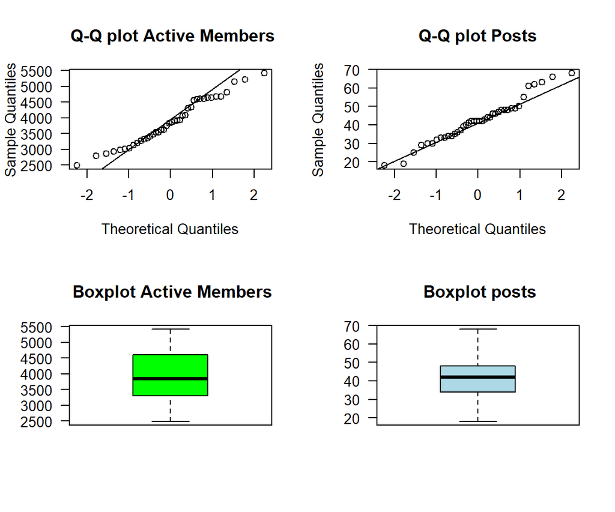

```r
# ** Appendix B

# Check the normality of the data.

par(mfrow = c(2,2)) # Setting Graphical Parameter to 3 columns/ 3 rows

# QQ plot to check the normality of the Active Members and Posts.
qqnorm(fbdata$Active.Members, las = 1 , main = " Q-Q plot Active Members", pch = 1) # QQ plot for active member.
qqline(fbdata$Active.Members)


qqnorm(fbdata$Posts,las = 1, main = "Q-Q plot Posts", pch = 1) # QQ Plot for the the Posts.
qqline(fbdata$Posts)


# Boxplot to check the outliers if there are any in the Active Members and Posts.

# Boxplot for the active members.
boxplot(fbdata$Active.Members, las = 1, main = " Boxplot Active Members", col = "green")

# Boxplot for the Posts.

boxplot(fbdata$Posts, las = 1, main = " Boxplot posts", col = "lightblue")
```

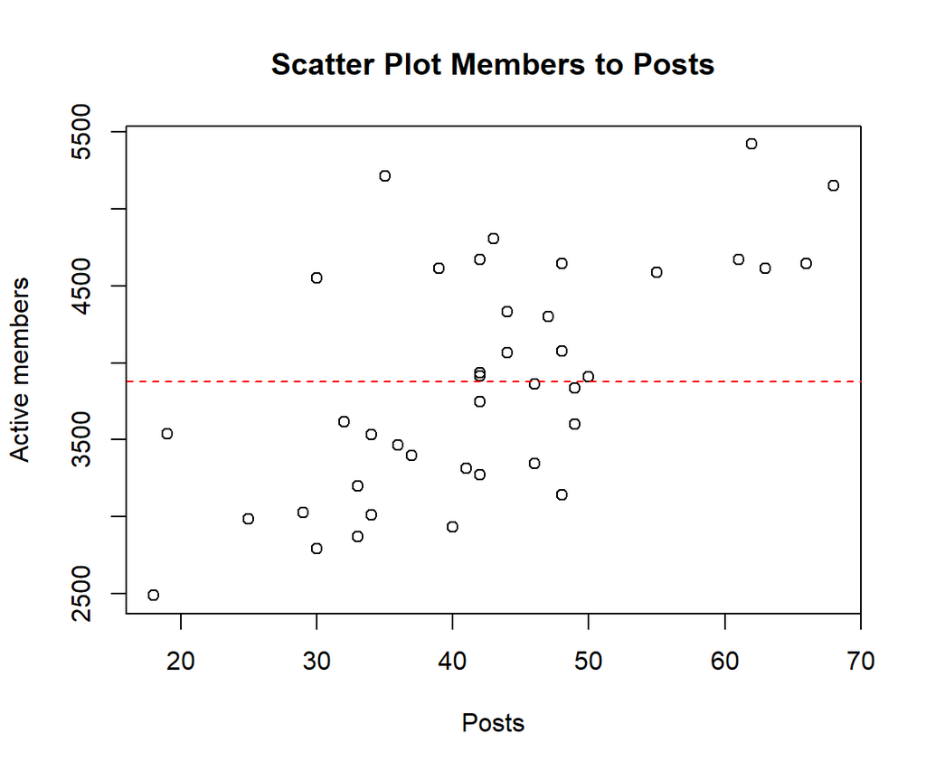

```r
# Scatterplot to visualise the relationship between Active Members and posts.

# Scatter plot to eyeball the data.
par(mfrow = c (1,1))
plot(fbdata$Posts,fbdata$Active.Members, xlab = "Posts", ylab = "Active members",
      main = "Scatter Plot Members to Posts")
abline(h = mean(fbdata$Active.Members), lty = 2, col = "red")
```

### **Performance of correlation test**

A correlation test is performed with the use of R function *“cor.test, Pearson’s parametric test”* between members and posts. Another test between members and comments(covariate) is performed using *“Kendall’s Non-parametric”* to see if they are monotonically related (refer to Appendix C for code). A correlation and causation effect with respect to lurking variable (comments) that correlates with the response(members) is also considered (Verzani, 2014, pp. 110-111). The results are discussed in Table 1.

```r
# Appendix C
print("Table 1:  Pearson's Product-moment correlation")
```

```
## [1] "Table 1:  Pearson's Product-moment correlation"
```

```r
# Correlation between posts and active member
cortestfb <-cor.test( fbdata$Posts, fbdata$Active.Members, conf.level = .95, method = "pearson")
print(cortestfb) # print the correlation test values
```

```
##
##  Pearson's product-moment correlation
##
## data:  fbdata$Posts and fbdata$Active.Members
## t = 5.2168, df = 38, p-value = 6.732e-06
## alternative hypothesis: true correlation is not equal to 0
## 95 percent confidence interval:
##  0.4187557 0.7971023
## sample estimates:
##       cor
## 0.6459971
```

```r
# Calculation of the t-statistic for the data.

alpha <- 0.05 #  The probability of committing a type 1 error.
n <- nrow(fbdata) # no of row into n vector

tstar <- qt(1-alpha/2, df = n-2) # calculation of the rejection region

print(paste(" The tstar is ± ", signif(tstar, 4)))
```

```
## [1] " The tstar is ±  2.024"
```

```r
# correlation between comments and active members

corfbcomment <- cor( fbdata$Comments, fbdata$Active.Members, method = "kendall")

print( paste (" The correlation coefficient r between comments and active members = ", signif(corfbcomment, 4))) # Print the r  for post and active members.
```

```
## [1] " The correlation coefficient r between comments and active members =  0.1599"
```

## **Results and discussion**

** Table 1 - Pearson’s product-moment correlation**

[output not shown]

### **Calculation of rejection region**

A rejection region t-star is calculated with 38 degree of freedom and $α = 0.05$ shown in the above table. The results used for discussion in *Table 1 and Table 2*.

### **Null Hypothesis and Assumptions**

A null hypothesis is where $β_{1} = 0$ and the alternative hypothesis is where $β_1≠ 0$. The linear model is represented by $Y_I=\hat{β_0}+ \hat{β_1}*X_I+ϵ^I$ where $β_{1}$ is a multiplicative variable representing slope. A t-test is conducted with results presented in Table 2 using *“lm”* function in *R*. Significance test for the hypothesis is $H_0: β_1 = 0; H_A: β_1≠ 0$. The probability of committing a *type 1 error is at a 5% significance level*, therefore the $α = 0.05$. The *F-statistics* has a distribution with $1$ and $n-2$ degree of freedom (Verzani, 2014, pp. 372-375)

### **Performing of linear regression analysis**

*“lm”* function in R is used to generate linear model object and output of the coefficient through *“summary”* function, where predictor(posts) to response (active members) is shown (refer to Appendix D).

The results are discussed in Table 2.

```r
#  Appendix D

# Linear Model(lm) function to find the linear regression of the model.

zmodel <- lm(Active.Members~Posts, data = fbdata)

 # summary function generate the summary of the F-statistic
print(paste(" The Linear-model statistics Table 2."))
```

```
## [1] " The Linear-model statistics Table 2."
```

```r
summary(zmodel)
```

```
##
## Call:
## lm(formula = Active.Members ~ Posts, data = fbdata)
##
## Residuals:
##    Min     1Q Median     3Q    Max
## -972.5 -336.8 -117.6  218.6 1638.7
##
## Coefficients:
##             Estimate Std. Error t value Pr(>|t|)
## (Intercept) 2132.540    346.673   6.151 3.53e-07 ***
## Posts         41.249      7.907   5.217 6.73e-06 ***
## ---
## Signif. codes:  0 '***' 0.001 '**' 0.01 '*' 0.05 '.' 0.1 ' ' 1
##
## Residual standard error: 576.7 on 38 degrees of freedom
## Multiple R-squared:  0.4173, Adjusted R-squared:  0.402
## F-statistic: 27.22 on 1 and 38 DF,  p-value: 6.732e-06
```

### **Confidence Interval Statistics**

```r
# confidence interval of the beta hat
confint(zmodel)
```

```
##                  2.5 %     97.5 %
## (Intercept) 1430.73667 2834.34283
## Posts         25.24225   57.25587
```

```r
# Using predict function values predicted values are generated and plotted against the real values.
```

### **Check the predicted value against the Normal values of Members**

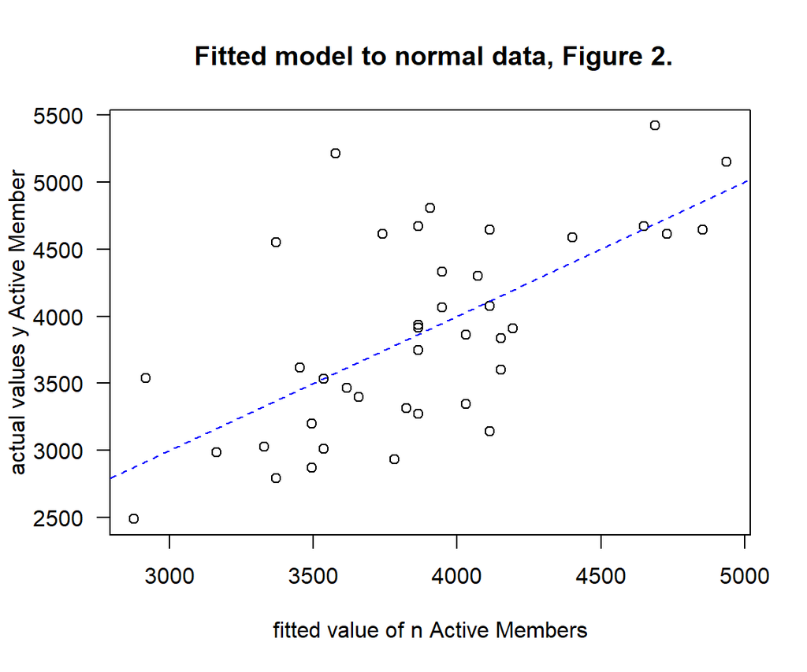

```r
# calculate the fitted model.

fitted.members <- fitted(zmodel)

# Calculate the residual values.

resid.member <- resid(zmodel)

# load the library "car" package to run the qq-plot.
# library(car).

# The plot is done at the end.
par(mfrow = c(1,1))

# Plot the fitted model against the normal data for the linear model.
plot(fitted.members, fbdata$Active.Members,las = 1, xlab = "fitted value of n Active Members",
     ylab = "actual values y Active Member", main = " Fitted model to normal data, Figure 2.")

abline(0,1, lty =2 , col = "blue")
```

### **Assess the residuals and validity assumptions of the linear model**

According to Verzani(2014), “The residuals are used to assess whether the error terms in the model are normally distributed” (p. 380). The model places assumption on the residuals, to check the normality of the distribution in the residuals.

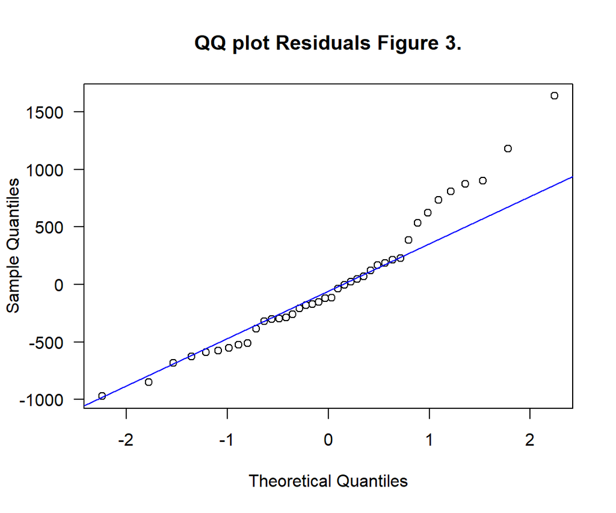

```r
# check the normality of the residual through plotting.

# QQ plot residual data through qq-norm and qq-line.

qqnorm(resid.member, main = "QQ plot Residuals Figure 3.", las = 1)
qqline(resid.member, col = "blue")
```

### **Third assumption “check the independence in the residuals and constant variance”.**

The third assumption is to check the independence in the residuals by plotting the residuals to check for patterns in the data which is shown in **Figure 4** to **5** bottom left. The data shows no sign of any pattern, which can be interpreted as independence in the variable which is valid (Verzani, 2014, pp.380-381)

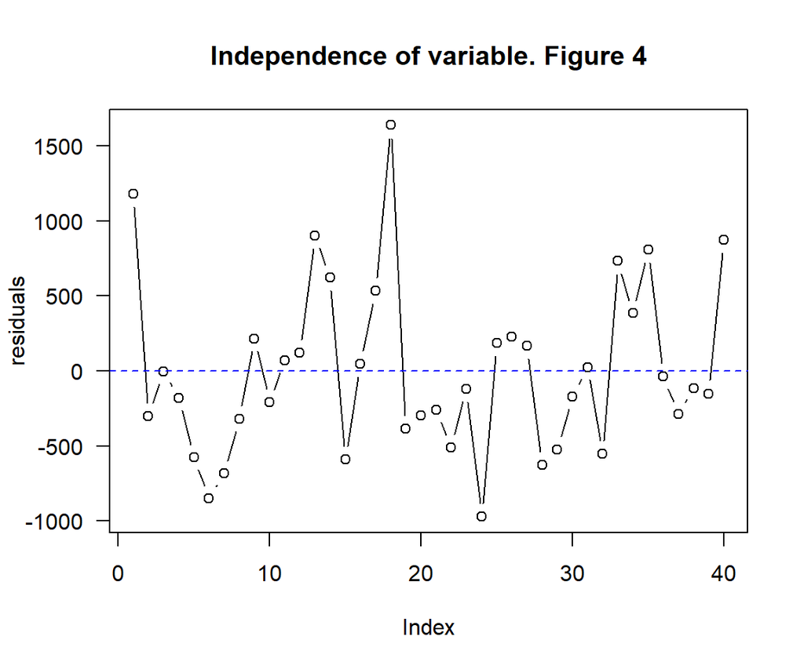

```r
# Plot to check independence of the variables.
plot(resid.member, type = "b", ylab = "residuals", las = 1, main = "Independence of variable. Figure 4")
abline(h = 0 ,lty = 2, col = "blue")
```

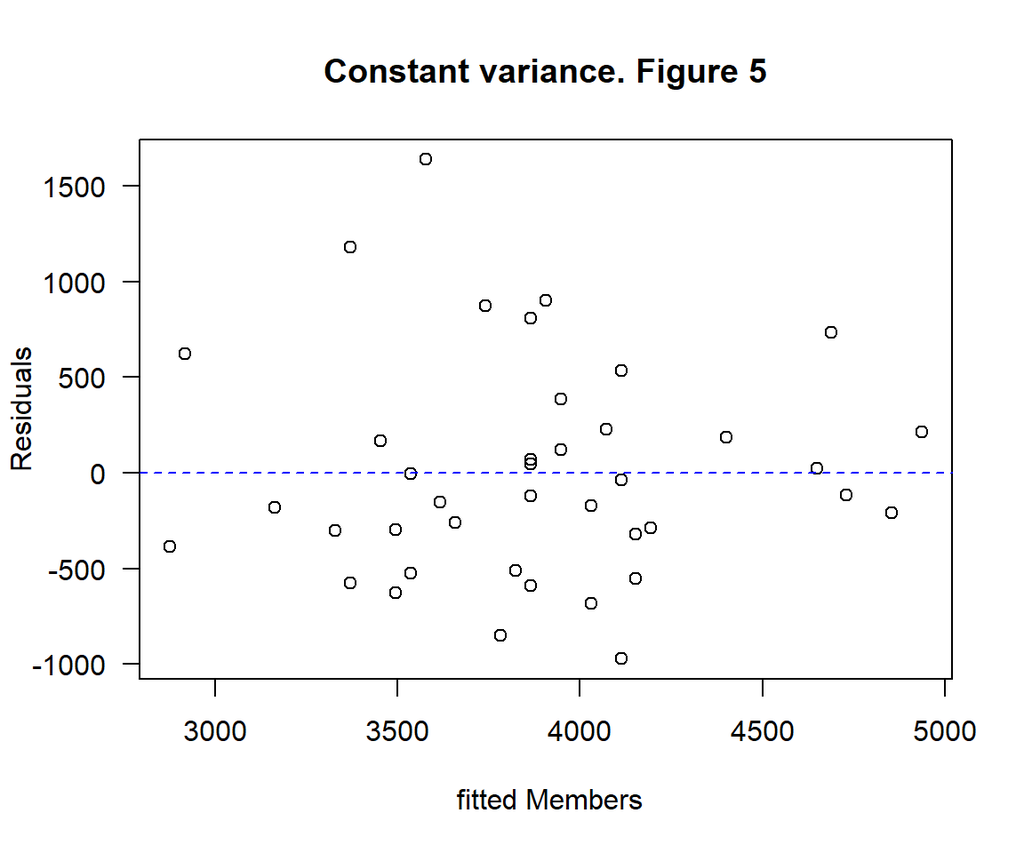

```r
# plot to check the constant variance of the data.

plot(fitted.members, resid.member, las = 1, xlab = " fitted Members", ylab = "Residuals", main = "Constant variance. Figure 5")
abline(h = 0 ,lty = 2, col = "Blue")
```

### **Regression test results analysis**

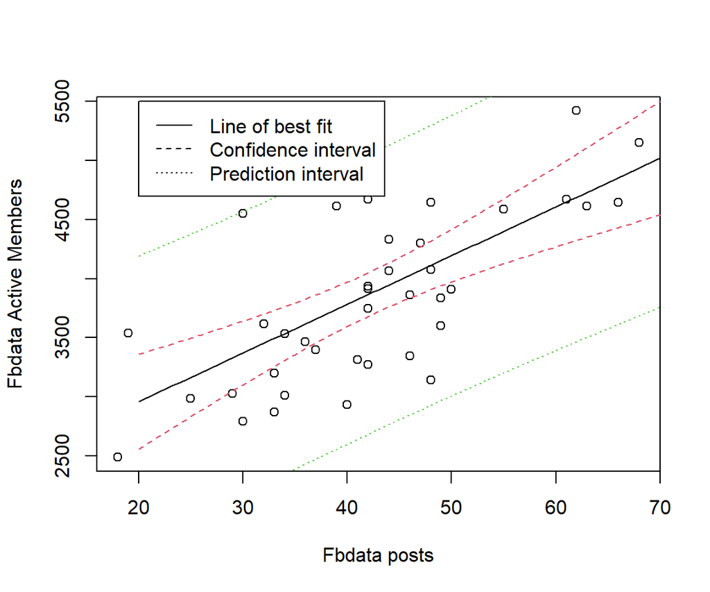

```r
# show the line of best fit and confidence and predictions bands for the model.

par(mfrow = c(1,1))
 xgrid <-  seq(20, 70, length.out=101) # Create seq from lowest of posts to highest output 101
 xgridframe <- data.frame(Posts=xgrid) # Create a data frame
 pc <- predict(zmodel, xgridframe, interval="confidence") # Create a confidence interval on z-model
 pp <- predict(zmodel, xgridframe, interval="prediction")# Create a prediction interval on z-model data
 fit <- pc[,1]
 # Plot the data with matlines to show the distribution
 plot(fbdata$Posts, fbdata$Active.Members, xlab="Fbdata posts", ylab="Fbdata Active Members")
 lines(xgrid, fit)
 matlines(xgrid, pc[,-1], col=2, lty=2)
 matlines(xgrid, pp[,-1], col=3, lty=3)
 # Placing a legend on the graph
 legend(20,5500, c("Line of best fit", "Confidence interval", "Prediction interval"), lty=c(1,2,3))
```

## **Conclusion**

Based on the evidence from the correlation test and regression test, it can be interpreted that there is a relationship between the post and the active members. The inherent limitation is space to perform further tests and the size of sample. A further transformation of data with square-root and use of a *Durbin Watson* test can give more insights into the data.

## **References**

Bartlett, J. (2014). R squared and goodness of fit in linear regression. Retrieved from

> https://thestatsgeek.com/2014/01/25/r-squared-and-goodness-of-fit-in-linear-regression/

Cutting, J. C. (2018). Reasoning in Psychology Using Statistics [Lab 20 HTML]. Retrieved from

> https://psychology.illinoisstate.edu/jccutti/psych138/sp19/labs/lab20.HTML

Dalgaard, P. (2015). ISwR: Introductory Statistics with R. R. (Version 2.0-7) [R package] Available from

> https://CRAN.R-project.org/package=ISwR

Florida State College at Jacksonville. (n.d.-b). STA 2023: Statistics: The Central Limit Theorem. Retrieved from

> https://guides.fscj.edu/Statistics/centrallimit Glen, S.(n.d.-c).

Statistics How To. Retrieved from

> https://www.statisticshowto.datasciencecentral.com/monotonic-relationship/

How to choose a sample size. (n.d.-a). Retrieved from

> http://www.tools4dev.org/resources/howto-choose-a-sample-size/

James Cook University. (2019a). MA5820: Statistical Methods for Data Scientists: week 6 notes (Parametric test – two independent samples t-test) [web page form]. Retrieved from

> https://learn.jcu.edu.au/ultra/courses/_104839_1/outline/lti/launchFrame?toolHref=https:%252F%252Flearn.jcu.edu.au%252Fwebapps%252Fblackboard%252Fexecute%252Fblt i%252FlaunchLink%3Fcourse_id%3D_104839_1%26content_id%3D_4161766_1%26fr om_ultra%3Dtrue

James Cook University. (2019b). MA5820: Statistical Methods for Data Scientists: week 4 notes (Linear regression modelling) [web page form]. Retrieved from

> https://learn.jcu.edu.au/ultra/courses/_104839_1/outline/lti/launchFrame?toolHref=https:%252F%252Flearn.jcu.edu.au%252Fwebapps%252Fblackboard%252Fexecute%252Fblt i%252FlaunchLink%3Fcourse_id%3D_104839_1%26content_id%3D_4161778_1%26fr om_ultra%3Dtrue RStudio Team (2015).

RStudio: Integrated Development for R. RStudio, Inc., Boston, MA. (Version R version 3.6.1) [R Software] Available from

> http://www.rstudio.com/.

Vemulapally, S. (2019). “MA5820: Assessment 2A Experimental Design on Facebook Posts and Active Member Relationship”. James Cook University, MA5820, Assessment 2A.

Verzani, J. (2014). Using r for introductory statistics. Retrieved from

> https://ebookcentral.proquest.com

Verzani, J.(2018) UsingR: Data Sets, Etc. for the Text “Using R for Introductory Statistics”, Second Edition. (Version 2.0-6) [R package]. Available from

> https://CRAN.R-project.org/package=UsingR